# Practical Machine Learning Course Assignment

Rachel Goodgold

November 1, 2017

## Background

Using devices such as JawboneUp, NikeFuelBand, and Fitbitit is now possible to collect a large amount of data about personal activity relatively inexpensively. These type of devices are part of the quantified self movement - a group of enthusiasts who take measurements about themselves regularly to improve their health, to find patterns in their behavior, or because they are tech geeks. One thing that people regularly do is quantify how much of a particular activity they do, but they rarely quantify how well they do it.

In this project, the goal is to use data from accelerometers on the belt, forearm, arm, and dumbell of 6 participants. They were asked to perform barbell lifts correctly and incorrectly in 5 different ways. More information is available from the website: http://groupware.les.inf.puc-rio.br/har (see the section on the Weight Lifting Exercise Dataset).

## Loading the data

```r
# Download the labeled data set if is not already in the working directory
if (file.exists("pmldata.csv")) {
    message("Data already downloaded")
    } else {message("Downloading data")
    download.file("https://d396qusza40orc.cloudfront.net/predmachlearn/pml-training.csv",
                  "pmldata.csv")
}
```

```
## Data already downloaded
```

```r
# Load the data into R
pmldata <- read.csv("pmldata.csv", na.strings=c("NA","#DIV/0!", ""))
dim(pmldata)
```

```
## [1] 19622   160
```

There are a total of 19622 observations and 160 columns in the labelled dataset. This dataset will be used to build and test the model.

```r
# Download the unlabeled data if is not already in the working directory
if (file.exists("validation.csv")) {
    message("Data already downloaded")
    } else {message("Downloading data")
    download.file("https://d396qusza40orc.cloudfront.net/predmachlearn/pml-testing.csv",
                  "validation.csv")
}
```

```
## Data already downloaded
```

```r
# Load the data into R
validation <- read.csv("validation.csv", na.strings=c("NA","#DIV/0!", ""))
dim(validation)
```

```
## [1]  20 160
```

The validation dataset has 20 observations and 160 columns. This dataset will be used to cross-validate the model.

## Cleaning the data

In this step, we will clean the dataset and get rid of observations with missing values as well as some meaningless variables.

### Removing Near Zero Variance variables

```r
NZV <- nearZeroVar(pmldata, saveMetrics = TRUE)
head(NZV, 20)
```

```
##                      freqRatio percentUnique zeroVar   nzv
## X                     1.000000  100.00000000   FALSE FALSE
## user_name             1.100679    0.03057792   FALSE FALSE
## raw_timestamp_part_1  1.000000    4.26562022   FALSE FALSE
## raw_timestamp_part_2  1.000000   85.53154622   FALSE FALSE
## cvtd_timestamp        1.000668    0.10192641   FALSE FALSE
## new_window           47.330049    0.01019264   FALSE  TRUE
## num_window            1.000000    4.37264295   FALSE FALSE
## roll_belt             1.101904    6.77810621   FALSE FALSE
## pitch_belt            1.036082    9.37722964   FALSE FALSE
## yaw_belt              1.058480    9.97349913   FALSE FALSE
## total_accel_belt      1.063160    0.14779329   FALSE FALSE
## kurtosis_roll_belt    2.000000    2.01304658   FALSE FALSE
## kurtosis_picth_belt   1.333333    1.60534094   FALSE FALSE
## kurtosis_yaw_belt     0.000000    0.00000000    TRUE  TRUE
## skewness_roll_belt    2.000000    2.00285394   FALSE FALSE
## skewness_roll_belt.1  1.333333    1.71236367   FALSE FALSE
## skewness_yaw_belt     0.000000    0.00000000    TRUE  TRUE
## max_roll_belt         1.000000    0.99378249   FALSE FALSE
## max_picth_belt        1.538462    0.11211905   FALSE FALSE
## max_yaw_belt          1.034483    0.33635715   FALSE FALSE
```

```r
pmldata <- pmldata[, !NZV$nzv]
validation <- validation[, !NZV$nzv]
dim(pmldata)
```

```
## [1] 19622   124
```

```r
dim(validation)
```

```
## [1]  20 124
```

The data sets now have 124 columns

### Removing unnecessary columns

```r
regex <- grepl("^X|timestamp|user_name", names(pmldata))
pmldata <- pmldata[, !regex]
validation <- validation[, !regex]
dim(pmldata)
```

```
## [1] 19622   119
```

```r
dim(validation)
```

```
## [1]  20 119
```

The data sets now have 119 columns

### Removing columns that contain NA’s

```r
cond <- (colSums(is.na(pmldata)) == 0)
pmldata <- pmldata[, cond]
validation <- validation[, cond]
dim(pmldata)
```

```
## [1] 19622    54
```

```r
dim(validation)
```

```
## [1] 20 54
```

Now, the labeled data set contains 19622 observations and 54 variables, while the unlabeled data set contains 20 observations and 54 variables.

## Partitioning the labeled data set

We split the cleaned labeled data set into a training data set (70%) and a testing data set (30%). We will use the validation data set to conduct cross-validation in future steps.

```r
set.seed(41894)
inTrain <- createDataPartition(pmldata$classe, p = 0.70, list = FALSE)
training <- pmldata[inTrain, ]
testing <- pmldata[-inTrain, ]
```

The Dataset now consists of 54 variables with the observations divided as following:  
1. Training Data: 13737 observation  
2. Testing Data: 5885 observations.  
3. Validation Data: 20 observations.

## Data Modeling

### Decision Tree

We fit a predictive model for activity recognition using the decision tree algorithm

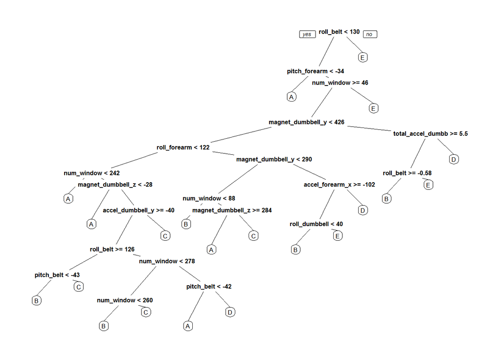

```r
modelTree <- rpart(classe ~ ., data = training, method = "class")
prp(modelTree)
```

Now, we estimate the performance of the model on the testing data set.

```r
predictTree <- predict(modelTree, testing, type = "class")
confusionMatrix(testing$classe, predictTree)
```

```
## Confusion Matrix and Statistics
##
##           Reference
## Prediction    A    B    C    D    E
##          A 1490   54    8   84   38
##          B  245  637   65  132   60
##          C   51   37  819   55   64
##          D   81   28  153  604   98
##          E   45   21   61  129  826
##
## Overall Statistics
##
##                Accuracy : 0.7436
##                  95% CI : (0.7322, 0.7547)
##     No Information Rate : 0.3249
##     P-Value [Acc > NIR] : < 2.2e-16
##
##                   Kappa : 0.6743
##  Mcnemar's Test P-Value : < 2.2e-16
##
## Statistics by Class:
##
##                      Class: A Class: B Class: C Class: D Class: E
## Sensitivity            0.7793   0.8198   0.7405   0.6016   0.7606
## Specificity            0.9537   0.9017   0.9567   0.9262   0.9467
## Pos Pred Value         0.8901   0.5593   0.7982   0.6266   0.7634
## Neg Pred Value         0.8998   0.9705   0.9409   0.9187   0.9459
## Prevalence             0.3249   0.1320   0.1879   0.1706   0.1845
## Detection Rate         0.2532   0.1082   0.1392   0.1026   0.1404
## Detection Prevalence   0.2845   0.1935   0.1743   0.1638   0.1839
## Balanced Accuracy      0.8665   0.8608   0.8486   0.7639   0.8536
```

```r
accuracy <- postResample(predictTree, testing$classe)
ose <- 1 - as.numeric(confusionMatrix(testing$classe, predictTree)$overall[1])
```

### Random Forest

We fit a predictive model for activity recognition using the random forest algorithm because it automatically selects important variables and is robust to correlated covariates & outliers in general.  
We will use 5-fold cross validation when applying the algorithm.

```r
modelRF <- train(classe ~ ., data = training, method = "rf", trControl = trainControl(method = "cv", 5), ntree = 250)
modelRF
```

```
## Random Forest
##
## 13737 samples
##    53 predictor
##     5 classes: 'A', 'B', 'C', 'D', 'E'
##
## No pre-processing
## Resampling: Cross-Validated (5 fold)
## Summary of sample sizes: 10991, 10990, 10989, 10990, 10988
## Resampling results across tuning parameters:
##
##   mtry  Accuracy   Kappa
##    2    0.9926473  0.9906985
##   27    0.9962145  0.9952117
##   53    0.9949773  0.9936467
##
## Accuracy was used to select the optimal model using  the largest value.
## The final value used for the model was mtry = 27.
```

Now, we estimate the performance of the model on the testing data set.

```r
predictRF <- predict(modelRF, testing)
confusionMatrix(testing$classe, predictRF)
```

```
## Confusion Matrix and Statistics
##
##           Reference
## Prediction    A    B    C    D    E
##          A 1673    0    0    0    1
##          B    2 1137    0    0    0
##          C    0    2 1024    0    0
##          D    0    0    4  960    0
##          E    0    0    0    5 1077
##
## Overall Statistics
##
##                Accuracy : 0.9976
##                  95% CI : (0.996, 0.9987)
##     No Information Rate : 0.2846
##     P-Value [Acc > NIR] : < 2.2e-16
##
##                   Kappa : 0.997
##  Mcnemar's Test P-Value : NA
##
## Statistics by Class:
##
##                      Class: A Class: B Class: C Class: D Class: E
## Sensitivity            0.9988   0.9982   0.9961   0.9948   0.9991
## Specificity            0.9998   0.9996   0.9996   0.9992   0.9990
## Pos Pred Value         0.9994   0.9982   0.9981   0.9959   0.9954
## Neg Pred Value         0.9995   0.9996   0.9992   0.9990   0.9998
## Prevalence             0.2846   0.1935   0.1747   0.1640   0.1832
## Detection Rate         0.2843   0.1932   0.1740   0.1631   0.1830
## Detection Prevalence   0.2845   0.1935   0.1743   0.1638   0.1839
## Balanced Accuracy      0.9993   0.9989   0.9978   0.9970   0.9990
```

```r
accuracy <- postResample(predictRF, testing$classe)
ose <- 1 - as.numeric(confusionMatrix(testing$classe, predictRF)$overall[1])
```

The Estimated Accuracy of the Random Forest Model is 99.76% and the Estimated Out-of-Sample Error is 0.24%. The Random Forests yielded better results, as expected!

## Predicting The Manner of Exercise for the Validation Data Set

Now, we apply the random forest model to the validation data set. We remove the problem_id column first.

```r
rm(accuracy)
rm(ose)
predict(modelRF, validation[, -length(names(validation))])
```

```
##  [1] B A B A A E D B A A B C B A E E A B B B
## Levels: A B C D E
```

## Generating Files to submit as answers for the Assignment

```r
pml_write_files = function(x){
  n = length(x)
  for(i in 1:n){
    filename = paste0("Problem_ID_",i,".txt")
    write.table(x[i], file = filename, quote = FALSE, row.names = FALSE, col.names = FALSE)
  }
}

pml_write_files(predict(modelRF, validation[, -length(names(validation))]))
```